# 第６回 属性Ⅰ 名前と次元

プログラミング演習Ⅰ

佐藤 秀保

sato0035@toyo.jp

## 先週までの内容

- リストを学習・・・list関数で生成

```r
list(1, 2, 3) #生成
lis <- list(1, 2, 3) #保存（代入）
```

- アトミックベクトルとの違い・・・異なる型・入れ子可

```r
list(1.1, 2L, TRUE, "文字") #異なる型
list(1, list(1, 2)) #入れ子
```

- データには長さがある・・・length関数で確認可

```r
length(list(1, 2)) #長さ2
length(list(c(1,2), list(1,2))) #長さ2
```

## 準備

1. [Posit Cloud](https://posit.cloud/)へ（日本語訳しないことを推奨）
2. 作成済みのプロジェクトをクリック
3. 先週使用のスクリプトをすべて閉じる
4. 新しくスクリプトを作成
5. 作成したスクリプトを保存：名前は「lec6」
6. ほうきボタンでオブジェクトを削除

授業中のコードはすべてスクリプトに書き実行すること

## 属性 attribute

- データは，**①型，➁長さ，③属性**の３つの特徴を有する
  - 属性とは，メタデータのこと
    - メタデータとは，データ自身の情報のこと
    - 例えば，スマホで撮影の画像データについて日付の情報はメタデータの１つ
- 属性で代表的なものは，**名前，次元，クラス**

### 名前 name

- 要素などに名前を付し，名前でその要素などを呼び出し
- 名前の付与
  1. アトミックベクトル生成時，c関数の中で
  2. アトミックベクトル生成時，setNames関数を使って
  3. アトミックベクトル生成後，names関数で

```r
vec_name1 <- c(a = 1, b = 2, c = 3) #1の方法
vec_name2 <- setNames(c(1, 2, 3), c("a", "b", "c")) #2の方法
vec_name3 <- c(1, 2, 3)
names(vec_name3) <- c("a", "b", "c") #3の方法
```

- Environmentペインには「Named」と明示される
- 名前の削除
  1. uname関数で
  2. names関数で名前にアクセスし，NULLで名前を上書き

```r
unname(vec_name1) #1の方法
names(vec_name2) <- NULL #2の方法
```

#### 演習

[JAタウン](https://www.ja-town.com/shop/f/f3020/)では産地直送でお米の販売を行っている．

現在，5kgの精米について，「栃木県産とちほのか」，「福井県産いちほまれ」，「滋賀県産みずかがみ」の価格はそれぞれ，6,310円，5,800円，5,100円である．

価格データを，名前を付した長さ３のnumericのアトミックベクトルrice_pricesとして保存せよ．ただし，名前はそれぞれ上記の産地と銘柄名の組み合わせとする．

### 次元 dimension

- データの構造を規定

| **次元数** | 同一の型 | 異なる型OK |
| --- | --- | --- |
| **1** | アトミックベクトル | リスト |
| **2** | 行列 | データフレーム |
| **3以上** | 配列 |  |

- アトミックベクトルに行数・列数を付与し，２次元の行列を作成しよう

#### 行列 matrix

- 二次元構造のデータ

|  | 列の名前１ | 列の名前２ | 列の名前３ |
| --- | --- | --- | --- |
| **行の名前１** | 1行1列目 | 1行2列目 | 1行3列目 |
| **行の名前２** | 2行1列目 | 2行2列目 | 2行3列目 |
| **行の名前３** | 3行1列目 | 3行2列目 | 3行3列目 |

- 表現について
  - 行方向・・・上下方向，列方向・・・左右方向
  - 行・・・row，列・・・column
- 行列データの生成①：dim関数を使用

```r
mat1 <- c(1, 2, 3, 4, 5, 6)
dim(mat1) <- c(2,3) #2行3列に変換
mat1 #呼び出して中身確認
```

```r
dim(mat1) <- c(3,2) #3行2列に変換
mat1 #呼び出して中身確認
```

- Environmentペインのmat1をクリックし，sourceペインでカタチを確認可
  - どの要素がどの位置に入っているか？
- 行列データの生成➁：matrix関数を使用
  - キーワード引数nrow，ncolにより行数，列数を指定
  - the **n**umber of **row**s, the **n**umber of **col**umns

```r
mat2 <- matrix(c(1, 2, 3, 4, 5, 6), nrow = 2, ncol = 3) #2行3列の行列生成
mat2 #呼び出して中身確認
```

#### 行列の長さと名前

- 長さや行数・列数の確認

```r
length(mat2)
nrow(mat2)
ncol(mat2)
```

- 行名・列名の付与
  - rownames関数，colnames関数で行名・列名にアクセスし，文字列のアトミックベクトルを代入することで付与

```r
rownames(mat2) <- c("row1", "row2")
colnames(mat2) <- c("col1", "col2", "col3")
mat2
```

#### 演習

2025年4月の学食における定食の売上額は「鶏のから揚げ定食」が最も高く，次に「シン・チキン南蛮定食」，その次に「半熟オムライス デミグラスソース」であり，順に537080円, 392840円, 231840円であった．

販売数でみると，「鶏のから揚げ定食」が926, 「シン・チキン南蛮定食」が644, 「半熟オムライス デミグラスソース」が368だった．

行名を商品名，列名を「売上額」，「販売数」とした3行2列の行列データgakusyokuを作成せよ．ただし，行における商品の順番は問わず自由とする．

完成例：

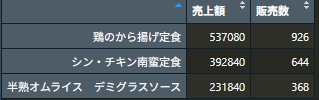

## 課題

- ACEの小テスト：「第６回」
- ACEのレポート：「第６回」
  - ローカルに保存したlec6.Rを提出